# ps4

Gustavo Gil

2/2/2018

CHAPTER 2

```r
library(tidyverse)
diamonds
```

```
## # A tibble: 53,940 x 10
##    carat cut       color clarity depth table price     x     y     z
##    <dbl> <ord>     <ord> <ord>   <dbl> <dbl> <int> <dbl> <dbl> <dbl>
##  1 0.230 Ideal     E     SI2      61.5  55.0   326  3.95  3.98  2.43
##  2 0.210 Premium   E     SI1      59.8  61.0   326  3.89  3.84  2.31
##  3 0.230 Good      E     VS1      56.9  65.0   327  4.05  4.07  2.31
##  4 0.290 Premium   I     VS2      62.4  58.0   334  4.20  4.23  2.63
##  5 0.310 Good      J     SI2      63.3  58.0   335  4.34  4.35  2.75
##  6 0.240 Very Good J     VVS2     62.8  57.0   336  3.94  3.96  2.48
##  7 0.240 Very Good I     VVS1     62.3  57.0   336  3.95  3.98  2.47
##  8 0.260 Very Good H     SI1      61.9  55.0   337  4.07  4.11  2.53
##  9 0.220 Fair      E     VS2      65.1  61.0   337  3.87  3.78  2.49
## 10 0.230 Very Good H     VS1      59.4  61.0   338  4.00  4.05  2.39
## # ... with 53,930 more rows
```

1. Carat is the most important variable in prdictig the price of diamonds. Carat and cut have a positive correlation in some cases and negative in other.

```r
regdiamond <- lm(price ~ carat + cut + color + clarity
               + depth + table, data = diamonds)
summary(regdiamond)
```

```
##
## Call:
## lm(formula = price ~ carat + cut + color + clarity + depth +
##     table, data = diamonds)
##
## Residuals:
##      Min       1Q   Median       3Q      Max
## -16828.8   -678.7   -199.4    464.6  10341.2
##
## Coefficients:
##              Estimate Std. Error  t value Pr(>|t|)
## (Intercept)  -969.661    360.432   -2.690  0.00714 **
## carat        8895.194     12.079  736.390  < 2e-16 ***
## cut.L         615.613     22.985   26.784  < 2e-16 ***
## cut.Q        -326.638     18.390  -17.762  < 2e-16 ***
## cut.C         156.333     15.814    9.886  < 2e-16 ***
## cut^4         -15.975     12.648   -1.263  0.20657
## color.L     -1908.010     17.718 -107.689  < 2e-16 ***
## color.Q      -626.087     16.112  -38.858  < 2e-16 ***
## color.C      -172.056     15.063  -11.423  < 2e-16 ***
## color^4        20.319     13.833    1.469  0.14187
## color^5       -85.245     13.068   -6.523 6.95e-11 ***
## color^6       -50.085     11.881   -4.216 2.50e-05 ***
## clarity.L    4206.854     30.867  136.290  < 2e-16 ***
## clarity.Q   -1831.804     28.811  -63.580  < 2e-16 ***
## clarity.C     919.725     24.672   37.278  < 2e-16 ***
## clarity^4    -361.609     19.728  -18.330  < 2e-16 ***
## clarity^5     213.910     16.108   13.280  < 2e-16 ***
## clarity^6       2.986     14.030    0.213  0.83148
## clarity^7     110.147     12.375    8.901  < 2e-16 ***
## depth         -21.024      4.079   -5.154 2.56e-07 ***
## table         -24.803      2.978   -8.329  < 2e-16 ***
## ---
## Signif. codes:  0 '***' 0.001 '**' 0.01 '*' 0.05 '.' 0.1 ' ' 1
##
## Residual standard error: 1156 on 53919 degrees of freedom
## Multiple R-squared:  0.9161, Adjusted R-squared:  0.916
## F-statistic: 2.942e+04 on 20 and 53919 DF,  p-value: < 2.2e-16
```

```r
regcarat.cut <- lm(carat ~ cut, data = diamonds)
summary(regcarat.cut)
```

```
##
## Call:
## lm(formula = carat ~ cut, data = diamonds)
##
## Residuals:
##     Min      1Q  Median      3Q     Max
## -0.8261 -0.3764 -0.1064  0.2580  3.9639
##
## Coefficients:
##              Estimate Std. Error t value Pr(>|t|)
## (Intercept)  0.859299   0.002983 288.033  < 2e-16 ***
## cut.L       -0.203597   0.007991 -25.478  < 2e-16 ***
## cut.Q        0.038498   0.007123   5.405 6.52e-08 ***
## cut.C       -0.135611   0.006199 -21.877  < 2e-16 ***
## cut^4       -0.045096   0.004998  -9.022  < 2e-16 ***
## ---
## Signif. codes:  0 '***' 0.001 '**' 0.01 '*' 0.05 '.' 0.1 ' ' 1
##
## Residual standard error: 0.4655 on 53935 degrees of freedom
## Multiple R-squared:  0.03546,    Adjusted R-squared:  0.03539
## F-statistic: 495.7 on 4 and 53935 DF,  p-value: < 2.2e-16
```

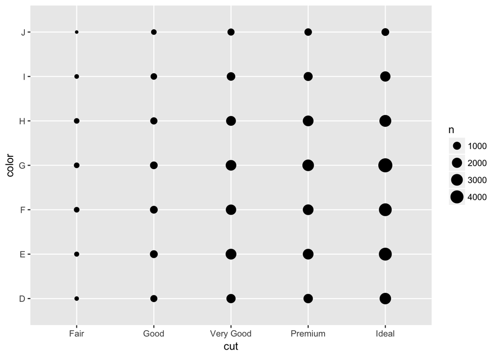

```r
ggplot(data = diamonds) +
  geom_count(mapping = aes(x = cut, y = color))
```

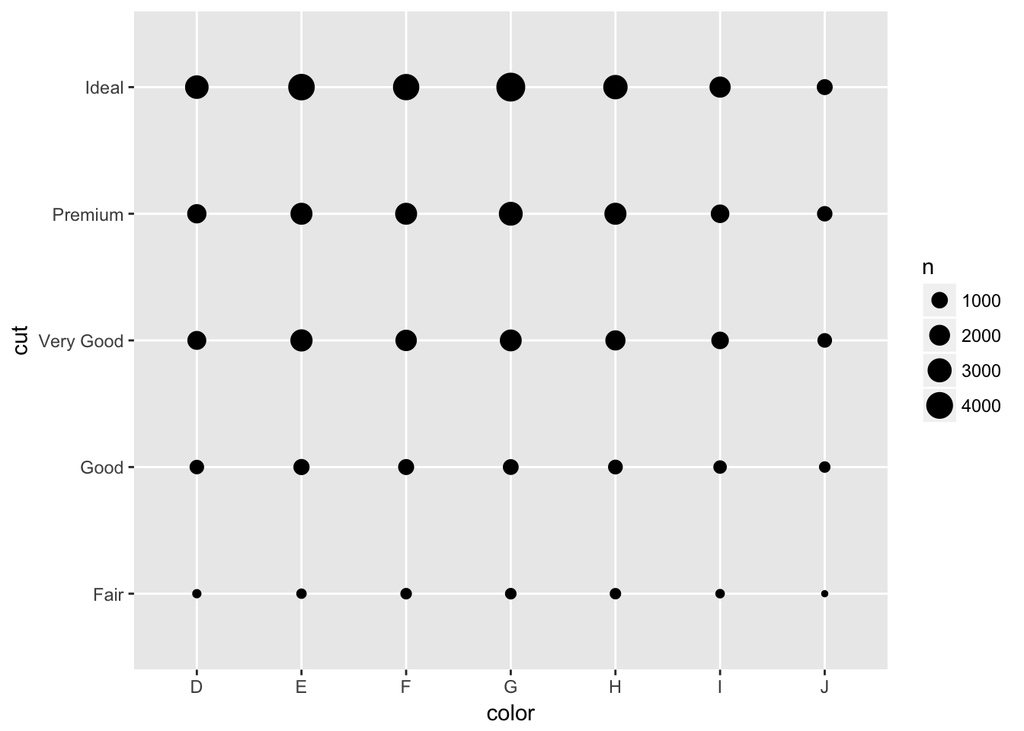

```r
ggplot(data = diamonds) +
  geom_count(mapping = aes(x = color, y = cut))
```

3. I think that it is easier to read the table when we use aes(x = color, y = cut). When we read a graph like this, we start from left to right, and having the name of the cut instead of only the letter that represents the color, makes it more intuitive for the user to read the data.

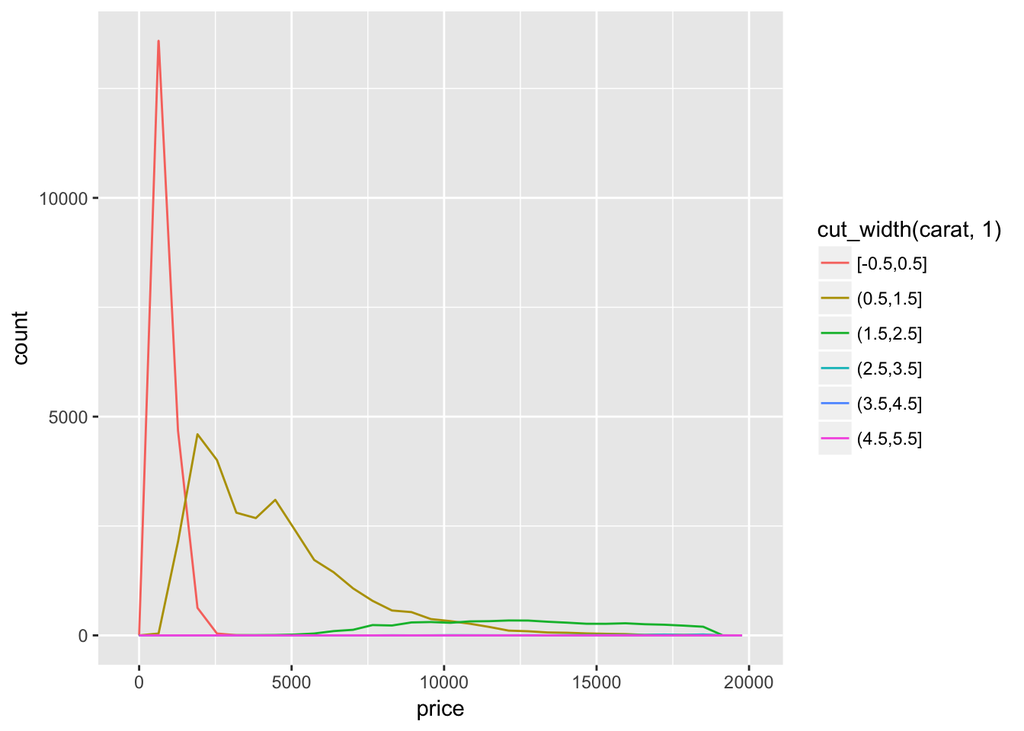

```r
ggplot(data = diamonds,
  mapping = aes(x = price, color = cut_width(carat, 1))) + geom_freqpoly()
```

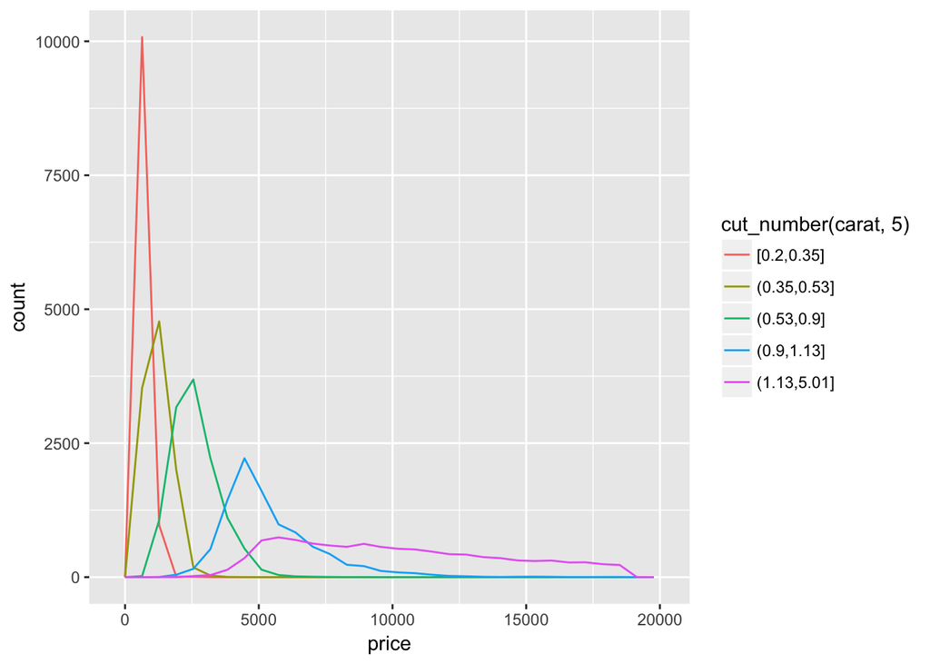

```r
ggplot(data = diamonds,
  mapping = aes(x = price, color = cut_number(carat, 5))) + geom_freqpoly()
```

4. In cut_width I need to consider the need to make specific analysis about different segments of the data; on cut_number, I want to know what are the most important groups by their number based on the recommendation of the software. The first will only be useful if the groupings have enough observations; thr second will be useful by software design, but might not be if we want to analyze an specific aspect of the data without enough observations.

6.The distribution of large diamonds is much more dispersed than small ones. I believe the reason is that the market of small diamonds must be indifferent about particular characteristics of the diamond; buyers are primarily interested in the low cost. Instead, the most the buyers are willing to pay for diamonds, they will not only be interested in the carat, but also in the cut, the color, the brand, etcetera.

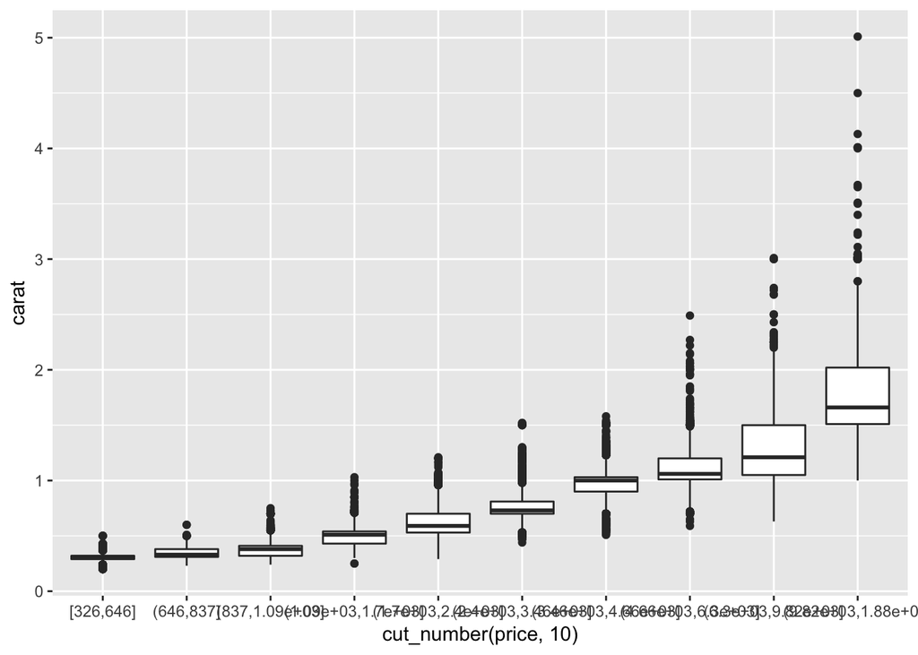

```r
ggplot(data = diamonds, aes(cut_number(price,10), y = carat)) + geom_boxplot()
```

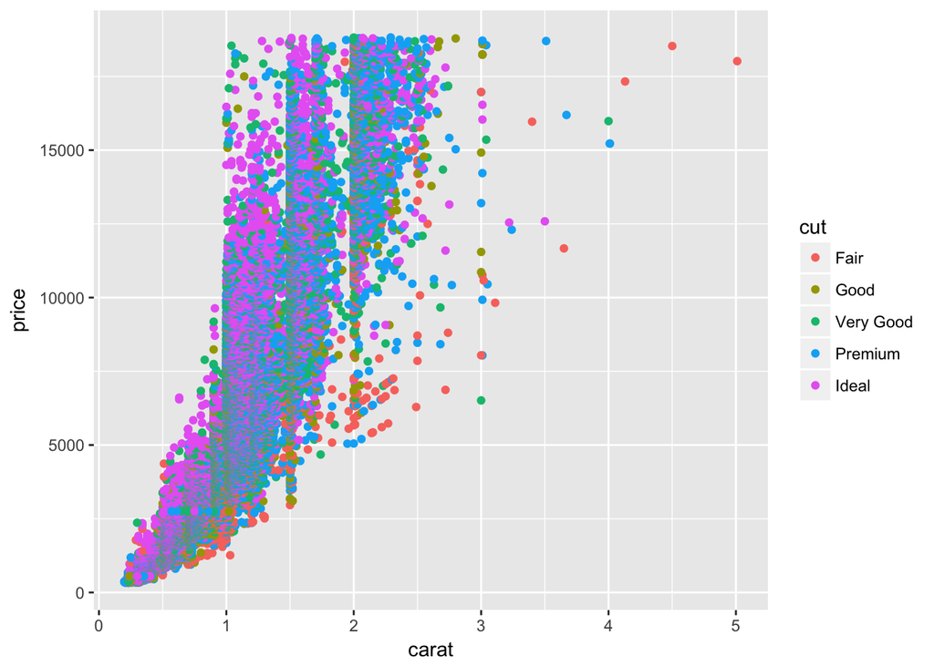

```r
ggplot(diamonds) + geom_point(aes(x = carat, y = price, color = cut))
```

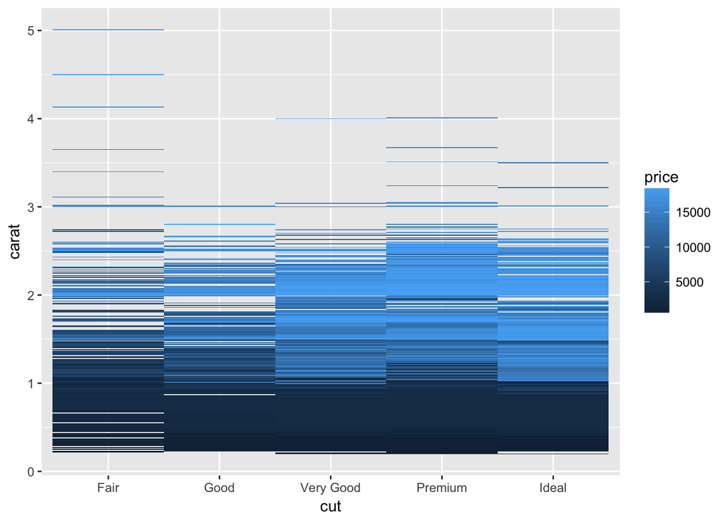

```r
ggplot(diamonds) + geom_tile(aes(x = cut, y = carat, fill = price))
```

8. In bins, the graph is much more visible where a high number of observations overlap. While in a scatterplot, individual observations are evident just by taking a look at the graph.

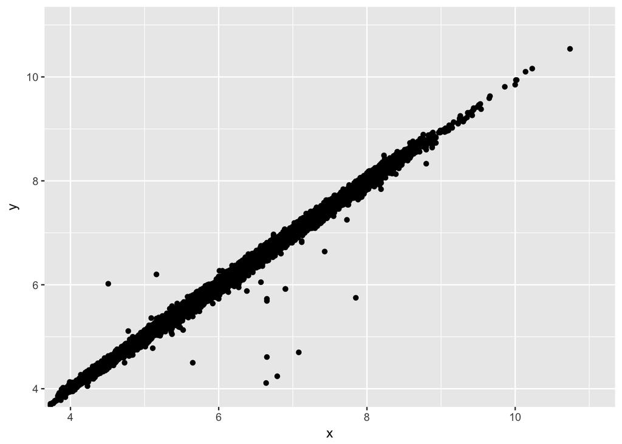

```r
ggplot(data = diamonds) +
geom_point(mapping = aes(x = x, y = y)) + coord_cartesian(xlim = c(4, 11), ylim = c(4, 11))
```

CHAPTER 10

1. We can know that an object is a tibble because its lists (the columns) are of the same lenght.

```r
mtcars
```

```
##                      mpg cyl  disp  hp drat    wt  qsec vs am gear carb
## Mazda RX4           21.0   6 160.0 110 3.90 2.620 16.46  0  1    4    4
## Mazda RX4 Wag       21.0   6 160.0 110 3.90 2.875 17.02  0  1    4    4
## Datsun 710          22.8   4 108.0  93 3.85 2.320 18.61  1  1    4    1
## Hornet 4 Drive      21.4   6 258.0 110 3.08 3.215 19.44  1  0    3    1
## Hornet Sportabout   18.7   8 360.0 175 3.15 3.440 17.02  0  0    3    2
## Valiant             18.1   6 225.0 105 2.76 3.460 20.22  1  0    3    1
## Duster 360          14.3   8 360.0 245 3.21 3.570 15.84  0  0    3    4
## Merc 240D           24.4   4 146.7  62 3.69 3.190 20.00  1  0    4    2
## Merc 230            22.8   4 140.8  95 3.92 3.150 22.90  1  0    4    2
## Merc 280            19.2   6 167.6 123 3.92 3.440 18.30  1  0    4    4
## Merc 280C           17.8   6 167.6 123 3.92 3.440 18.90  1  0    4    4
## Merc 450SE          16.4   8 275.8 180 3.07 4.070 17.40  0  0    3    3
## Merc 450SL          17.3   8 275.8 180 3.07 3.730 17.60  0  0    3    3
## Merc 450SLC         15.2   8 275.8 180 3.07 3.780 18.00  0  0    3    3
## Cadillac Fleetwood  10.4   8 472.0 205 2.93 5.250 17.98  0  0    3    4
## Lincoln Continental 10.4   8 460.0 215 3.00 5.424 17.82  0  0    3    4
## Chrysler Imperial   14.7   8 440.0 230 3.23 5.345 17.42  0  0    3    4
## Fiat 128            32.4   4  78.7  66 4.08 2.200 19.47  1  1    4    1
## Honda Civic         30.4   4  75.7  52 4.93 1.615 18.52  1  1    4    2
## Toyota Corolla      33.9   4  71.1  65 4.22 1.835 19.90  1  1    4    1
## Toyota Corona       21.5   4 120.1  97 3.70 2.465 20.01  1  0    3    1
## Dodge Challenger    15.5   8 318.0 150 2.76 3.520 16.87  0  0    3    2
## AMC Javelin         15.2   8 304.0 150 3.15 3.435 17.30  0  0    3    2
## Camaro Z28          13.3   8 350.0 245 3.73 3.840 15.41  0  0    3    4
## Pontiac Firebird    19.2   8 400.0 175 3.08 3.845 17.05  0  0    3    2
## Fiat X1-9           27.3   4  79.0  66 4.08 1.935 18.90  1  1    4    1
## Porsche 914-2       26.0   4 120.3  91 4.43 2.140 16.70  0  1    5    2
## Lotus Europa        30.4   4  95.1 113 3.77 1.513 16.90  1  1    5    2
## Ford Pantera L      15.8   8 351.0 264 4.22 3.170 14.50  0  1    5    4
## Ferrari Dino        19.7   6 145.0 175 3.62 2.770 15.50  0  1    5    6
## Maserati Bora       15.0   8 301.0 335 3.54 3.570 14.60  0  1    5    8
## Volvo 142E          21.4   4 121.0 109 4.11 2.780 18.60  1  1    4    2
```

2. Unlike the data frame from the code chunk that gives the observation of the column “xyz”, when calling for printing the “column” x in tibble, results in the following message “Unknown or uninitialised column: ‘x’.NULL”.

```r
d_f <- data.frame(abc = 1, xyz = "a")
```

```r
d_f$x
```

```
## [1] a
## Levels: a
```

```r
d_f[, "xyz"]
```

```
## [1] a
## Levels: a
```

```r
d_f[, c("abc", "xyz")]
```

```
##   abc xyz
## 1   1   a
```

```r
d.f <- tibble (
abc = 1,
xyz = "a"
)
```

```r
d.f$x
```

[output not shown]

```r
d.f[, "xyz"]
```

```
## # A tibble: 1 x 1
##   xyz
##   <chr>
## 1 a
```

```r
d.f[, c("abc", "xyz")]
```

```
## # A tibble: 1 x 2
##     abc xyz
##   <dbl> <chr>
## 1  1.00 a
```

3. We can extract the reference variable by using the column number in which it is located. If its location is the first column, then we can use names(x)[1]
4. We can convert simple named vectors into tibbles with enframe(). See (https://tjmahr.github.io/tibble-package-tour/=). I migh use it when I want to transfor a particular result from some caculation on a tibble into another tibble.
5. options(tibble.print_max = n, tibble.print_min = m) is the control option for the additional names of columns that are printed, tibble.print_max = n which defines the maximum amount of column names we want to see.

CHAPTER 11

1. I would use read.cvs(data, sep = “|”)
2. The most important arguments are the path to the file (file); the column positions (col_positions); specify the type of the column (col_types); the locale default in case the data will be used in a country outside the US; specify the missing values in case of existence. There are other arguments that have to be used in case of special conditions of the data frame imported.
3. In order to read “x,y1,‘a,b’” in a data frame, we would need to specify the following arguments: the file path; “,” as the delim argument; “’”" as the single character that quotes the string; escape_backlash = TRUE.
4. read_csv(“a,b,c1,2,34,5,6”) read_csv(“a,b,c1,2,12,3,4”) read_csv(“a,b1,.”, na = “.”) read_csv(“a,b1,2.,.”, na = “.”) read_csv(“a,b1,3”)
5. date_format and time_format are the default arrangement formats for a country.